# Problem Set 1

Note: Grading is based both on your graphs and verbal explanations. Follow all best practices as discussed in class, including choosing appropriate parameters for all graphs. *Do not expect the assignment questions to spell out precisely how the graphs should be drawn. Sometimes guidance will be provided, but the absense of guidance does not mean that all choices are ok.*

Read *Graphical Data Analysis with R*, Ch. 3

### 1. Fast Food

[6 points]

Data: *fastfood* in **openintro** package

1. Draw multiple horizontal boxplots of `calories`, by `restaurant`. What do you observe?

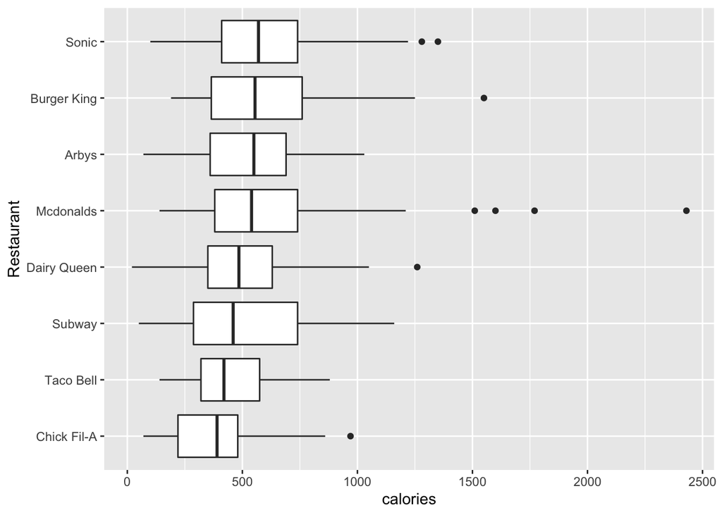

```r
library(tidyverse)
library(openintro)
ggplot(fastfood, aes(fct_reorder(restaurant, calories), calories)) +
  geom_boxplot() +
  coord_flip() + xlab('Restaurant')
```

2. Draw histograms, faceted by `restaurant`, for the same data. Describe one insight that was not visible in the boxplots.

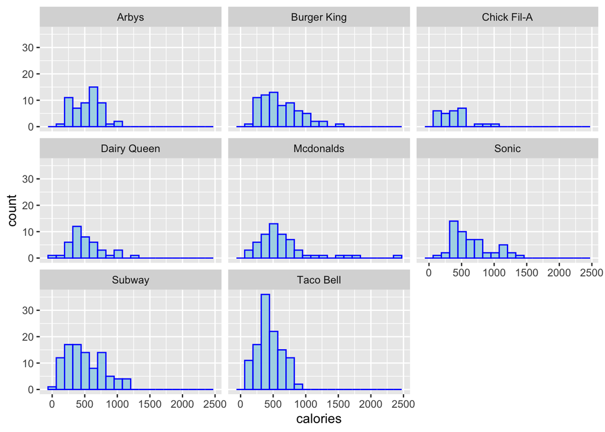

```r
fastfood %>%
ggplot(aes(calories)) +
  geom_histogram(bins = 20, color = "blue", fill = "lightblue") +
  facet_wrap(~restaurant)
```

There are a few things we can learn by looking at the histograms. First, Chick Fil-A seems to have the least amount of items offered, while Taco Bell has the most. Additionally we can tell the distribution of the calorie count of items. McDonalds, Burger King, Dairy Queen, and Sonic are right skewed, whereas the calorie count of items at Taco Bell are more normally distributed. The calorie count of items at Chick Fil-A create two different uniform distributions - one between 0-500 cals and the other 750-1000 cals. The calorie count of items at Arbys, Subway, and Sonic can be considered bimodal, whereas most other restaurants are essentially unimodal.

3. Do crispy items have more calories than grilled items? Create a new variable, `cooktype` that is “Crispy” if the item name contains “Crispy” and “Grilled” if it contains “Grilled”. (Leave out any items that contain both or neither.) Hint: useful functions: `filter()`, `str_detect()`, `xor()`. Next plot overlapping density curves of `calories`, one curve for Crispy and one curve for Grilled, on a single set of axes. Each curve should be a different color. What do you observe?

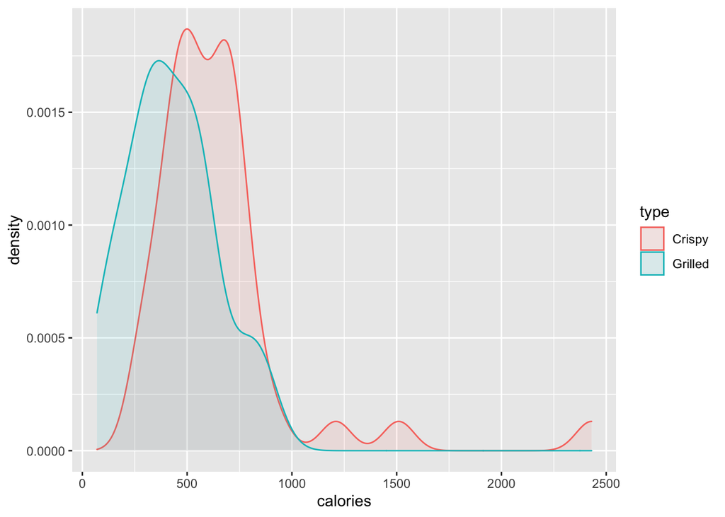

```r
fastfood2 <- fastfood %>%
  filter(xor(str_detect(item, "Grilled"), str_detect(item, "Crispy"))) %>%
  mutate(type = ifelse(str_detect(item, "Crispy"), "Crispy", "Grilled"))

ggplot(fastfood2, aes(calories, color = type, fill = type)) +
  geom_density(alpha = .1)
```

Crispy items do contain more calories than grilled items. The modes of the cripy items are about 500 and 700 cals, whereas the mode of grilled items is at about 350 cals. Additionally, the high-calorie items (items with more than 1000 cals) are all cripsy items.

### 2. Temporal Lobes

[4 points]

Data: *mtl* in **openintro** package

1. Draw two histograms–one with base R and the other with **ggplot2**–of the variable representing the thickness of the subiculum subregion of the medial temporal lobe without setting any parameters. What is the default method each uses to determine the number of bins? (For base R, show the calculation.) Which do you think is a better choice for this dataset and why?

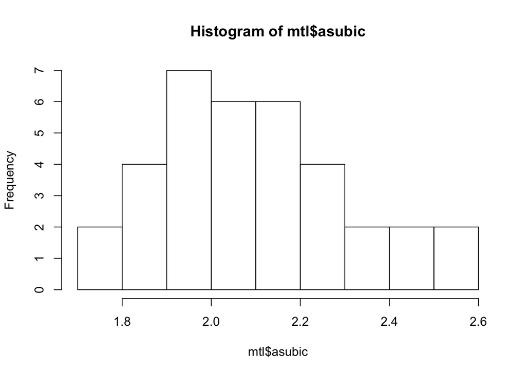

```r
hist(mtl$asubic)
```

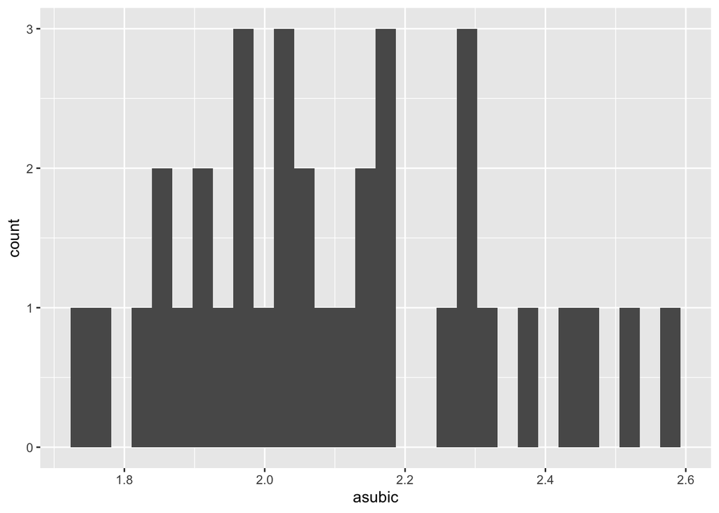

```r
ggplot(mtl, aes(asubic)) +
  geom_histogram()
```

The default method for R hist is to determine the breaks using the “Sturges” function, which calculates the number of bins $k=Ceil(\log_2(n)) + 1$, where $n$ is the number of datapoints. For this dataset there should be 7 bins, however due to something with the pretty() function, R is using 9 bins instead. For a more in depth explanation of what goes on behind the scenes of hist, check out https://planspace.org/20141225-how_does_r_calculate_histogram_break_points/ Geom_hist has a default of 30 bins. The R hist function is better for this dataset as with this function, we can focus on the overall shape of the distribution of asubic values.

2. Draw two histograms of the `age` variable with boundaries at multiples of 5, one right closed and one right open. Every boundary should be labeled (45, 50, 55, etc.)

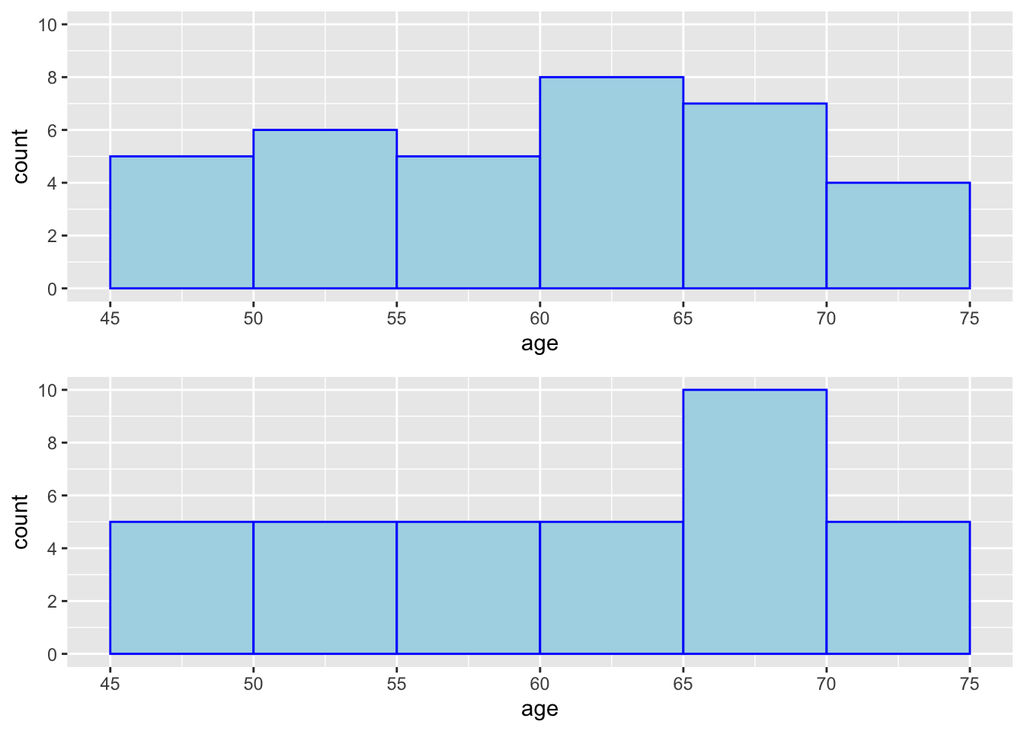

```r
g1 <- ggplot(mtl, aes(age)) + geom_histogram(color = "blue", fill = "lightblue", binwidth = 5,
                                             boundary = 50, closed = "right") +
  scale_x_continuous(breaks = seq(45, 75, 5)) +
  scale_y_continuous(limits = c(0, 10), breaks = seq(0, 10, 2))

g2 <- ggplot(mtl, aes(age)) + geom_histogram(color = "blue", fill = "lightblue", binwidth = 5,
                                             boundary = 50, closed = "left") +
  scale_x_continuous(breaks = seq(45, 75, 5)) +
  scale_y_continuous(limits = c(0, 10), breaks = seq(0, 10, 2))

gridExtra::grid.arrange(g1, g2)
```

3. Adjust parameters–the same for both–so that the right open and right closed versions become identical. Explain your strategy.

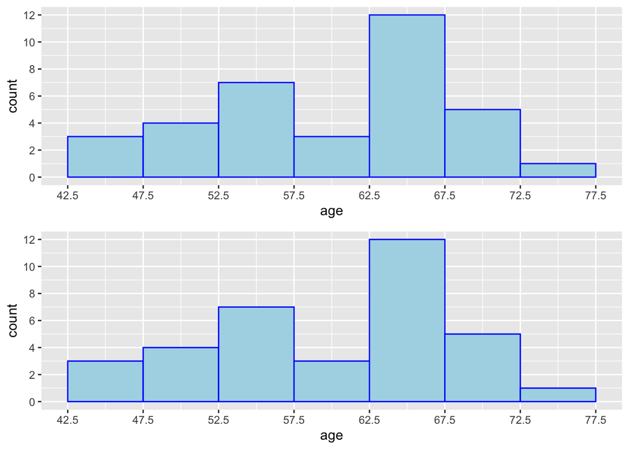

```r
g1 <- ggplot(mtl, aes(age)) + geom_histogram(color = "blue", fill = "lightblue", binwidth = 5,
                                             boundary = 52.5, closed = "right") +
  scale_x_continuous(breaks = seq(42.5, 77.5, 5)) +
  scale_y_continuous(limits = c(0, 12), breaks = seq(0, 12, 2))

g2 <- ggplot(mtl, aes(age)) + geom_histogram(color = "blue", fill = "lightblue", binwidth = 5,
                                             boundary = 52.5, closed = "left") +
  scale_x_continuous(breaks = seq(42.5, 77.5, 5))+
  scale_y_continuous(limits = c(0, 12), breaks = seq(0, 12, 2))


gridExtra::grid.arrange(g1, g2)
```

All the ages are integers. Choosing an integer boundary that some of the data are divisible by (chosen to be 5 in part b) puts some of the data on the boundary values and thus those data points fall into different histogram bins depending on whether the histogram is left or right closed. Setting the boundary to be non-integer (52.5 in part b), none of the data can lie on a boundary value, meaning that the right and left closed histograms are the same.

### 3. Soybeans

[8 points]

Data: *australia.soybean* in **agridat** package

1. Use QQ (quantile-quantile) plots with theoretical normal lines to compare `yield` for the four locations (`loc`). For which location does the `yield` appear to be closest to a normal distribution?

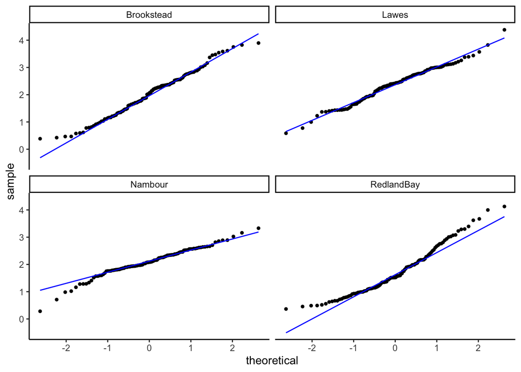

```r
library(agridat)
ggplot(australia.soybean, aes(sample = yield)) +
  geom_qq(size = 1) +
  geom_qq_line(color = "blue") +
  facet_wrap(~loc) +
  theme_classic()
```

Lawes seems to have the most normally distributed yield distribution. Brookstead also is closely normally distributed, however the tails of the yield distribution stray slightly further away from a normal distribution than in Lawes.

2. Draw density histograms with density curves and theoretical normal curves overlaid of `yield` for the four locations. Option 1:

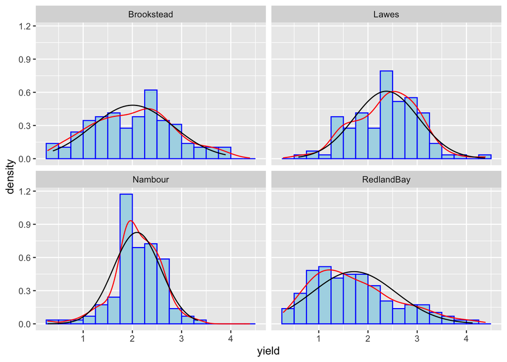

```r
stats <- australia.soybean %>% group_by(loc) %>%
  summarize(mean = mean(yield), sd = sd(yield))

australia.soybean %>%
  group_by(loc) %>%
  mutate(x = seq(min(yield), max(yield), length.out = length(yield))) %>% # create x's to use with geom_line()
  ungroup() %>%
  ggplot(aes(yield)) +
  geom_histogram(aes(y = ..density..), color = "blue", fill = "lightblue", binwidth = .25,
                 boundary = 0) +
  geom_density(col='red') +
  geom_line(aes(x = x, y = dnorm(x, mean = stats$mean[loc], sd = stats$sd[loc])), col = "black")+
  facet_wrap(~loc)
```

Option 2:

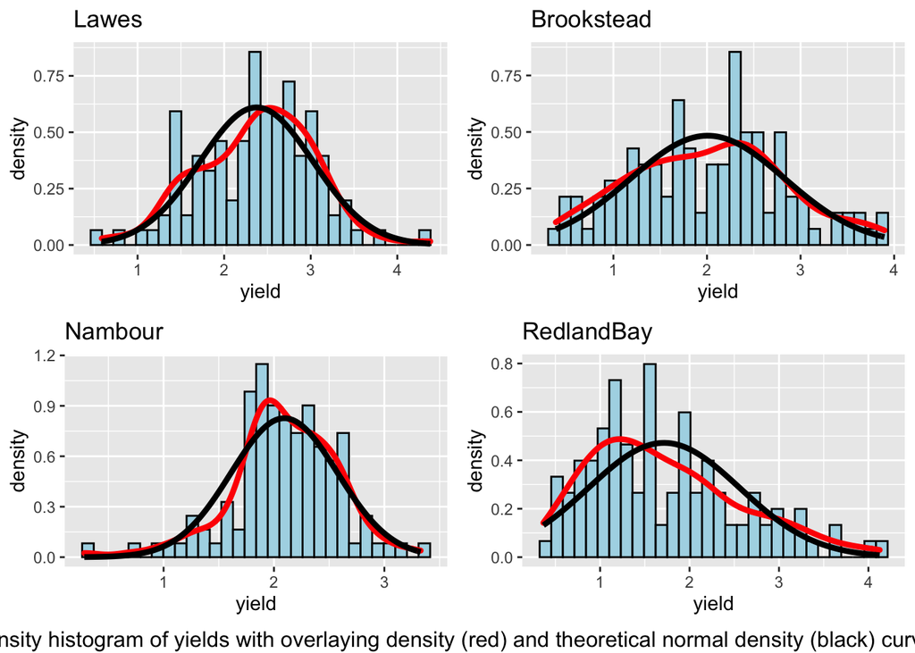

```r
lawes <- australia.soybean %>% filter(loc=='Lawes')
Brookstead <- australia.soybean %>% filter(loc=='Brookstead')
Nambour <-  australia.soybean %>% filter(loc=='Nambour')
RedlandBay <-  australia.soybean %>% filter(loc=='RedlandBay')

g1 <- ggplot(lawes, aes(x=yield)) +
  geom_histogram(fill='lightblue', col='black', aes(y=..density..)) +
  geom_density(col = "red", lwd=1.5) +
  stat_function(fun = dnorm, color="black", lwd=1.5,
                args = list(mean = mean(lawes$yield), sd = sd(lawes$yield))) +
  ggtitle("Lawes")

g2 <- ggplot(Brookstead, aes(x=yield)) +
  geom_histogram(fill='lightblue', col='black', aes(y=..density..)) +
  geom_density(col = "red", lwd=1.5) +
  stat_function(fun = dnorm, color="black", lwd=1.5,
                args = list(mean = mean(Brookstead$yield), sd = sd(Brookstead$yield))) +
  ggtitle("Brookstead")

g3 <- ggplot(Nambour, aes(x=yield)) +
  geom_histogram(fill='lightblue', col='black', aes(y=..density..)) +
  geom_density(col = "red", lwd=1.5) +
  stat_function(fun = dnorm, color="black", lwd=1.5,
                args = list(mean = mean(Nambour$yield), sd = sd(Nambour$yield))) +
  ggtitle("Nambour")

g4 <- ggplot(RedlandBay, aes(x=yield)) +
  geom_histogram(fill='lightblue', col='black', aes(y=..density..)) +
  geom_density(col = "red", lwd=1.5) +
  stat_function(fun = dnorm, color="black", lwd=1.5,
                args = list(mean = mean(RedlandBay$yield), sd = sd(RedlandBay$yield))) +
  ggtitle("RedlandBay")

library(ggpubr)
annotate_figure(ggarrange(g1, g2, g3, g4, ncol = 2, nrow = 2), bottom = "Density histogram of yields with overlaying density (red) and theoretical normal density (black) curves")
```

3. Perform Shapiro-Wilk tests for normality for `yield` for each location using the `shapiro.test()` function and interpret the results.

```r
australia.soybean %>% group_by(loc) %>%
  summarize(p.value = shapiro.test(yield)$p.value)
```

```
## # A tibble: 4 x 2
##   loc         p.value
##   <fct>         <dbl>
## 1 Brookstead 0.259
## 2 Lawes      0.328
## 3 Nambour    0.0191
## 4 RedlandBay 0.000412
```

The null hypothesis for the Shapiro-Wilk test for normality is that the popultation the data are sampled from is normally distributed. Thus if the p-value is significantly small (typical significant values are 0.05 and 0.01), then we would reject the null hypothesis and claim the data are not normally distributed.

The p-values for Brookstead and Lawes were 0.259 and 0.328 respectively. Regardless of the significance values used, the Shapiro-Wilk test does not reject the hypothesis that the yields are normally distributed in these locations. The p-value for Nambour is 0.0191. Under the more common significant value of 0.05. we would reject the null hypothesis and claim that the dataset does not come from a normally distributed population. Under the significant value of 0.01, we would fail to reject the null hypothesis and thus continue under the assumption that the data do come from a normally distributed population. Finally, the p-value for RedlandBay was essentially 0, and thus we would reject the null hypothesis under all signficance values.

4. Did all of the methods for testing for normality (a, b, and c) produce the same results? Briefly explain.

### 4. Doctors

[4 points]

Data: *breslow* dataset in **boot** package

Draw two histograms of the number of deaths attributed to coronary artery disease among doctors in the *breslow* dataset, one for smokers and one for non-smokers. )Hint: read the help file `?breslow` to understand the data.)

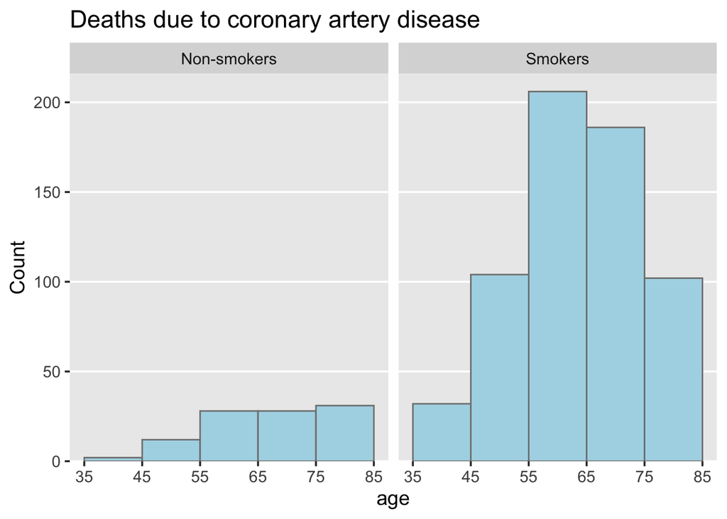

```r
library(boot)
death <- breslow %>%
  mutate(smoke = factor(smoke)) %>%
  mutate(smoke = fct_recode(smoke, `Non-smokers` = "0", Smokers = "1"),
         age = as.numeric(as.character(age)))


ggplot(death, aes(age, y)) +
  geom_col(color = "grey50", fill = "lightblue", width = 10) +
  scale_x_continuous(breaks = seq(35, 85, 10)) +
  scale_y_continuous(expand = c(0,0,0,10)) +
  facet_wrap(~smoke) +
  ylab("Count") +
  ggtitle("Deaths due to coronary artery disease") +
  theme_grey(14) +
  theme(panel.grid.major.x = element_blank(), panel.grid.minor = element_blank())
```

### 5. Loans

[8 points]

Data: *loans_full_schema* in **openintro** package

1. Use appropriate techniques to describe the distribution of the `loan_amount` variable noting interesting features.

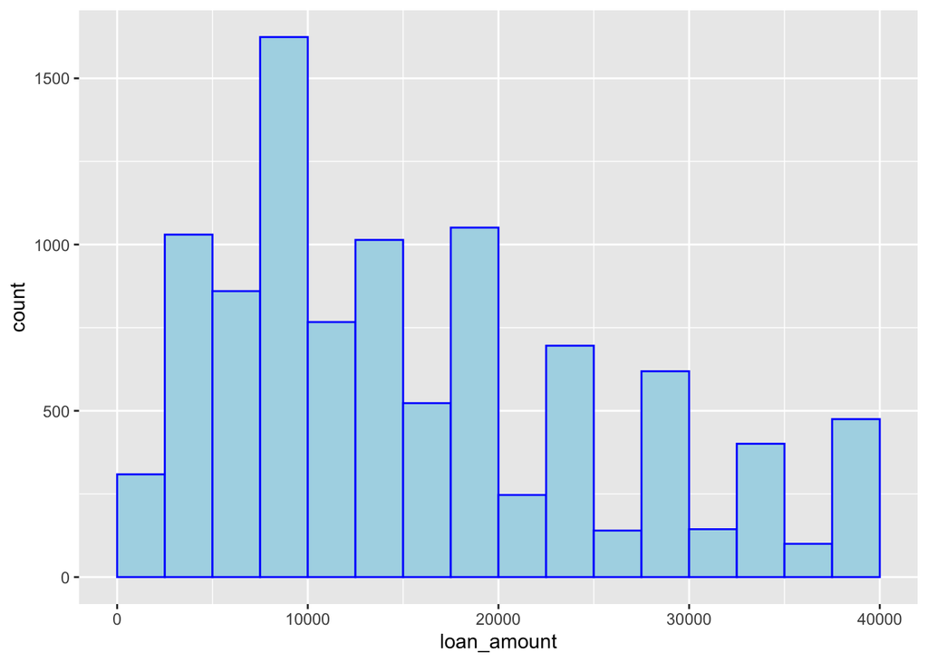

```r
ggplot(loans_full_schema, aes(loan_amount)) +
  geom_histogram(color = "blue", fill = "lightblue", breaks = seq(0, 40000, 2500))
```

From the histogram, we can see that the data is overall right-skewed. After about $10,000, loan amounts seem to be predominantly multiples of $5,000 such as $35,000, $40,000.

2. Create horizontal boxplots of `loan_amount`, one for each level of `loan_purpose`.

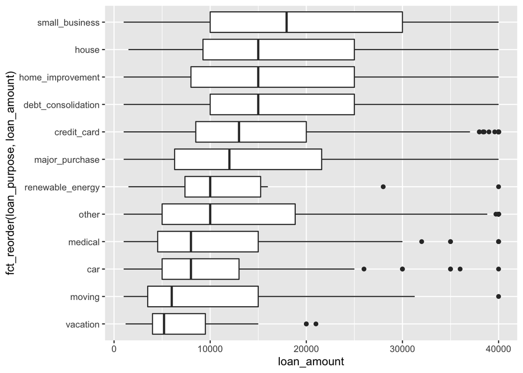

```r
ggplot(loans_full_schema, aes(x = fct_reorder(loan_purpose, loan_amount), y = loan_amount)) +
  geom_boxplot() +
  coord_flip()
```

3. Create ridgeline plots (package **ggridges**) for the same data as in b).

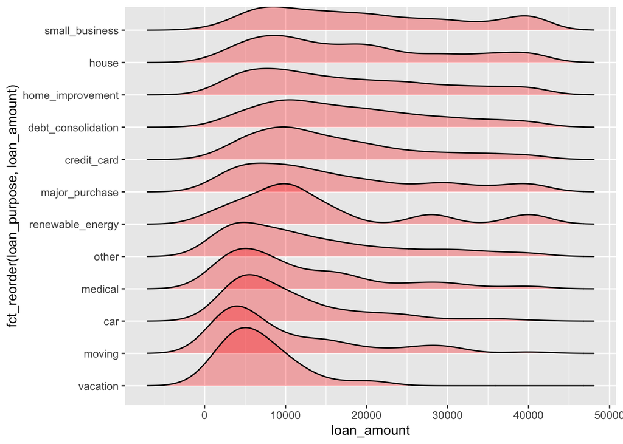

```r
library(ggridges)
ggplot(loans_full_schema, aes(loan_amount, fct_reorder(loan_purpose, loan_amount))) +
  geom_density_ridges(fill = "red", alpha = .3)
```

4. Compare b) and c). Which do you think is more effective for this data and why?

The high loan amounts of $40,000 are easier to see using the boxplots in part b. However, the ridgelines in part c allow us to see the distributions of the data, which gives us some interesting insight. For instance small business loans are essentially uniformly distributed from $10,000 to $40,000, with a bump at $40,000. Renewable energy loans are tri-modal, with modes at $10,000, $27,500, and $40,000. These modes and bumps are lost in the boxplots, as you cannot tell how many outliers there are at a specific loan amount. This goes along with the insight from part a, where we could see the majority of loans were multiples of $5,000.